# Homework 2 and 3 by Nasibe Deniz & Merve Esin

Nasibe Deniz & Merve Esin

# Part A

# Part B

btrain = tuketim[169:36480,]  
bminus48 = tuketim[121:36432,]  
bminus168 = tuketim[1:36312,]  
bminus48$Tarih <- NULL bminus48$Saat <- NULL  
bminus168$Tarih <- NULL bminus168$Saat <- NULL  
long_format <- cbind(btrain,bminus48,bminus168)  
as.data.frame(long_format)  
colnames(long_format) <- c(“Date”,“Hour”,“Consumption”,“Lag48”,“Lag168”)  
colnames(table) <- c(“Date”,“Hour”,“Consumption”,“Lag48”,“Lag168”)  
long_format_test = table  
head(long_format_test)  
train_long_format = long_format[,-c(1,2)]  
test_long_format = long_format_test[,-c(1,2)]  
lin_mod=lm(Consumption~.,train_long_format)  
predicted=predict(lin_mod,test_long_format)  
plot(test_long_format$Consumption,predicted)  
summary(lin_mod)

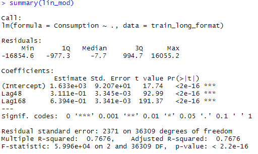

And we used our model to predict the test data. Results are shown on the graph below:

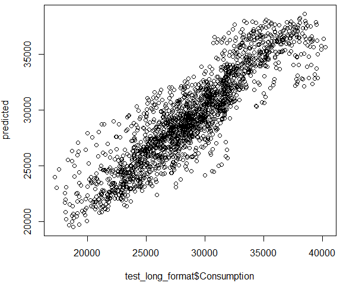

# Part C

train_0 = filter(long_format,Hour == “00:00”)  
train_0 = train_0[,-c(1,2)]  
test_0 = filter(long_format_test, Hour == “00:00”)  
test_0 = test_0[,-c(1,2)]  
lin_mod_0 = lm(Consumption~.,train_0)  
predicted_0 = predict(lin_mod_0,test_0)  
plot(test_0$Consumption,predicted_0)  
summary(lin_mod_0)

One by one, we filtered our train data to create hourly train datas. We did the same thing for our test datas. Then, we created a **linear model** for each hour of the day with our train datas. We tested these models on the corresponding test datas. All 24 results are listed below:

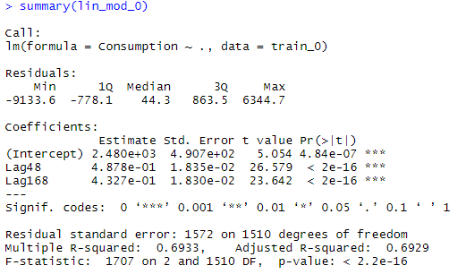

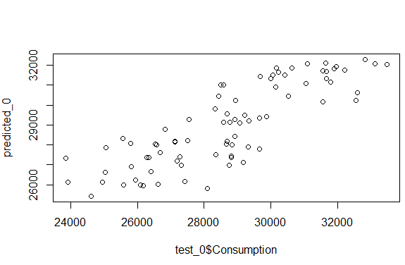

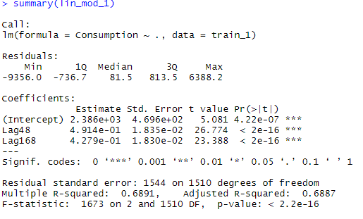

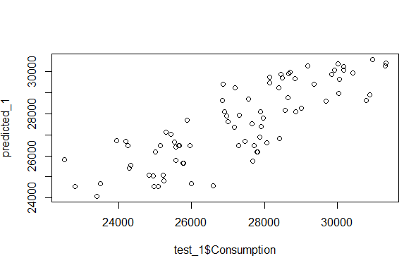

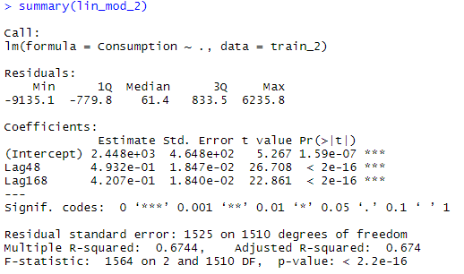

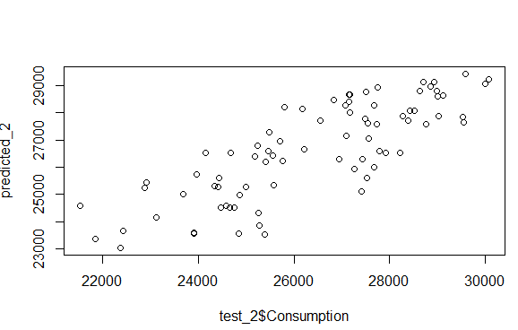

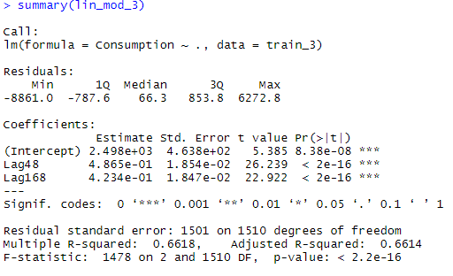

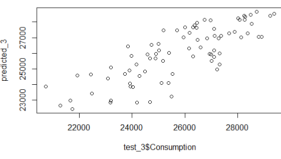

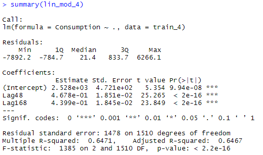

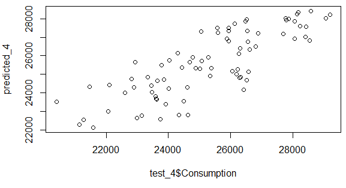

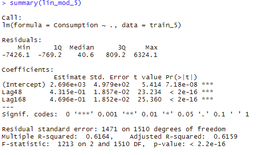

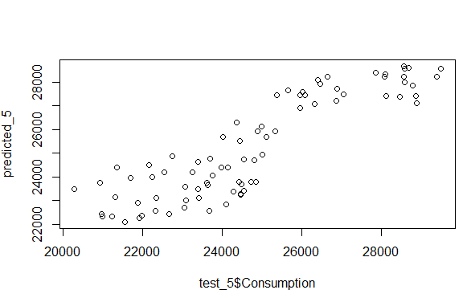

[38 more figures not shown]

[Link to our code](https://github.com/ETM-58D/spring20-nsbdeniz)  
[Link to our code](https://github.com/ETM-58D/spring20-mmerveesin)

Nasibe Deniz & Merve Esin